# STA 2202- Time Series Analysis- Graduate Project

Bharadwaj Janarthanan | bharadwaj@cs.toronto.edu | 1005068720

20 December 2018

To run this code we would need the following packages installed (if not already installed on system)

1. Rssa
2. Keras (https://keras.rstudio.com/, Check link for installation)

   ```
   install.packages("keras")
   install_keras()
   ```

3. data.table
4. parallel
5. fpp
6. tidyverse

*Note:The code takes about 8 hours to complete a run on a system with 16 GB RAM, i7-8th Gen processor and Nvidia GeForce GTX 1050Ti, 4GB GPU for the entire data.*

## Importing Web Traffic Data- Wikipedia Pages

This section includes modules to import Wikpedia pages daily views data. It then identifies page attributes and separates it out from the data.

```r
filename<-"./train_englishWiki100.csv"
#Import Web Traffic Data
web_data<-read.table(filename,header=TRUE,stringsAsFactors = FALSE,sep=",")
web_data$X<-NULL
colnames(web_data)[1]<-str_to_lower(colnames(web_data)[1])
web_data<-web_data[web_data$page %like% "en.wikipedia.org",]
setDT(web_data)

#Split page to access/agent/location/page name

web_data[,webcode:=as.character(page)]

#Agent
web_data[,agent:=str_extract(page,"\\_([:alpha:]|\\-)*$")]
web_data[,page:=str_remove_all(page,agent)]
web_data[,agent:=str_replace_all(agent,"\\_","")]

#Access
web_data[,access:=str_extract(page,"\\_([:alpha:]|\\-)*$")]
web_data[,page:=str_remove_all(page,access)]
web_data[,access:=str_replace_all(access,"\\_","")]

#Location
web_data[,location:=str_extract(page,"((\\_www.mediawiki.org)|(\\_commons\\.wikimedia\\.org)|(\\_([:alpha:]){0,2}\\.wikipedia\\.org))$")]
web_data[,page:=str_remove_all(page,location)]
web_data[,location:=str_replace_all(location,"\\_","")]

#Store Characteristic information in separate dataset
web_info_data<-data.table(unique(data.frame(web_data[,.(webcode,page,agent,access,location)])))

#Remove all the characteristic information from the web series data
web_data[,`:=`(page=NULL,agent=NULL,access=NULL,location=NULL)]

#Melt data to Page X Daily format
web_data<-as.data.table(melt(web_data,id=c("webcode")))
colnames(web_data)<-str_to_lower(colnames(web_data))

#Column format
web_data[,date:=as.character(variable)]
web_data[,date:=str_replace_all(date,"X","")]
web_data[,date:=as.Date(date,format="%Y.%m.%d")]
web_data[,pageviews:=as.numeric(value)]
web_data[,`:=`(variable=NULL,value=NULL)]

save(web_info_data,file="./ENG_Web_Attributes.RData")
save(web_data,file="./ENG_Web_PageViews_WebPageXDate.RData")
```

## Exploratory Data Analysis

This section contains modules to perform a few basic exploratory analysis on wikipedia page daily hits, to understand the variations in data better. Some of the analyses here are inspired from the views in, [https://tools.wmflabs.org/pageviews/?project=en.wikipedia.org&platform=all-access&agent=user&range=latest-20&pages=Cat|Dog](https://tools.wmflabs.org/pageviews/?project=en.wikipedia.org&platform=all-access&agent=user&range=latest-20&pages=Cat%7CDog)

A lot more information on traffic analysis can be found at, https://meta.wikimedia.org/wiki/Pageviews_Analysis

Articles/Pages spike in traffic because of,  
1. Media Attention  
2. Time of the year  
3. Bots/ Spider crawling through the pages  
and so on…

Note: If there’s time a missing data imputation technique would be tried out to see how that improves the model performance.

```r
#Finding Missing Data
sum(is.na(web_data$pageviews))/(nrow(web_data))
```

```
## [1] 0.1086052
```

**Web Agents:**

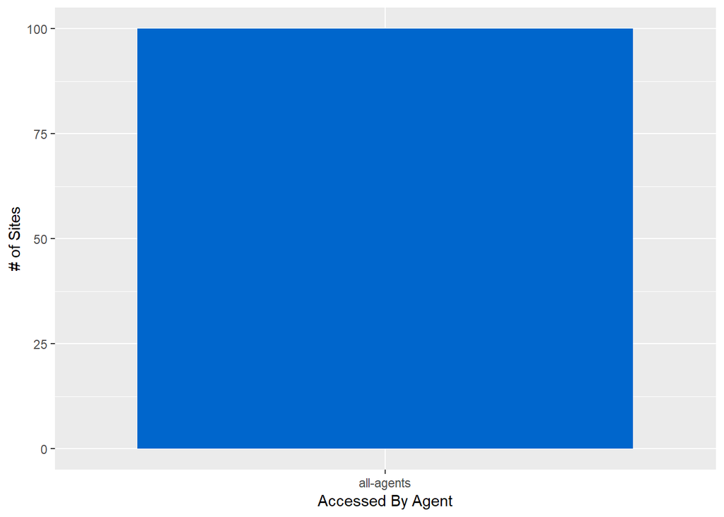

```r
ggplot(data=web_info_data)+
  aes(x=agent)+
  geom_bar(fill="#0066CC")+
  xlab("Accessed By Agent")+
  ylab("# of Sites")
```

**Web Access:**

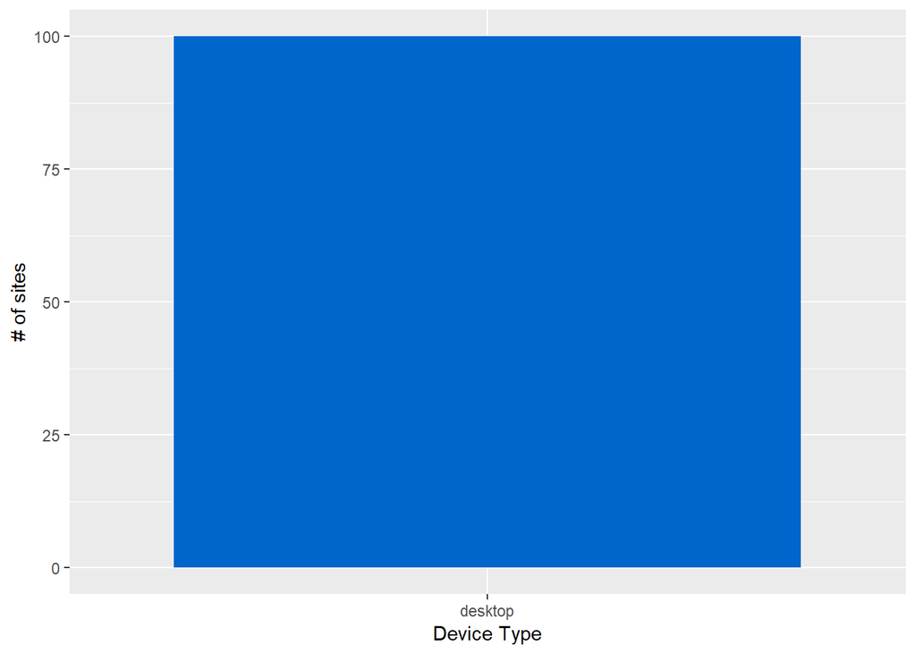

```r
ggplot(data=web_info_data)+
  aes(x=access)+
  geom_bar(fill="#0066CC")+
  xlab("Device Type")+
  ylab("# of sites")
```

**Overall Web Traffic Time Series Plot:**

```r
#Summarise Web Page Traffic- Overall
web_daily_summary_dat<-web_data%>%
  group_by(date)%>%
  summarise(avg_webviews=mean(pageviews,na.rm=TRUE),
            median_webviews=median(pageviews,na.rm=TRUE),
            sd_webviews=sd(pageviews,na.rm=TRUE),
            no_webpages=n_distinct(webcode),
            total_webviews=sum(pageviews,na.rm=TRUE))%>%
  mutate(year=year(date))

save(web_daily_summary_dat,file="./ENG_WebTraffic_Overall_Daily_Summary.RData")
rm(web_daily_summary_dat)
```

**Plot of overall web traffic data summary:**

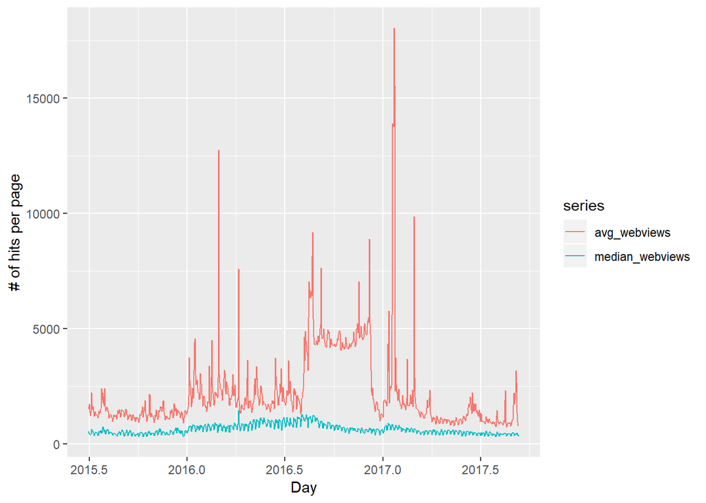

```r
load("./ENG_WebTraffic_Overall_Daily_Summary.RData")
inds <- seq(as.Date("2015-07-01"), as.Date("2017-09-10"), by = "day")
web_daily_ts_summary_dat<-ts(data.matrix((web_daily_summary_dat[,2:3])),frequency = 365,start=c(2015,as.numeric(format(inds[1], "%j"))))
autoplot(web_daily_ts_summary_dat,xlab="Day",ylab="# of hits per page")
```

The above plot shows, the median vs average page hits in a day for all provided Wikipedia data and as can be seen, the medians are not as varying as the averag hits per page, which means a large number of Wikipedia pages seem to have a very strong pattern (Trend, Seasonality) to their hits/views. However, some pages experience sudden spike in traffic and this spikes up the overall page hits. Plotting the variation in traffic in a day across pages shows, how different are the traffic across wikipedia pages.

**Plot of standard deviation in webpage views in a day:**

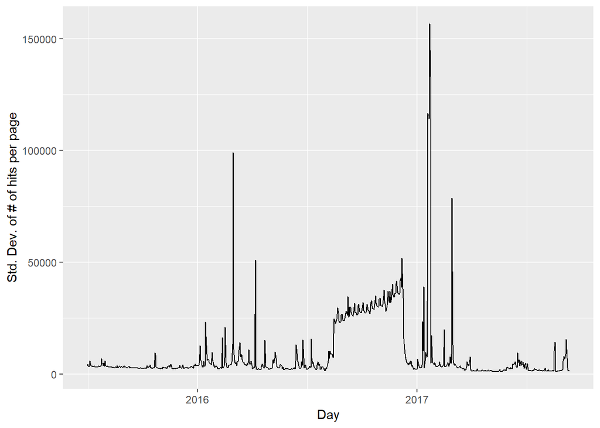

```r
web_daily_ts_summary_dat<-ts(data.matrix((web_daily_summary_dat[,4])),frequency = 365,start=c(2015,as.numeric(format(inds[1], "%j"))))
autoplot(web_daily_ts_summary_dat,xlab="Day",ylab="Std. Dev. of # of hits per page")
```

As can be seen, the web-traffic data across page are quite different, with some of those pages with extreme highly traffic

**Decomposition of Overall Traffic Data:**

Before decomposing the overall web-traffic data, we need to check if the data is stationary using a KPSS test,

```r
web_daily_avg_ts_summary_dat<-ts(data.matrix(log1p(web_daily_summary_dat[,2])),frequency = 365,start=c(2015,as.numeric(format(inds[1], "%j"))))
kpss.test(web_daily_avg_ts_summary_dat,null="Trend")
```

```
##
##  KPSS Test for Trend Stationarity
##
## data:  web_daily_avg_ts_summary_dat
## KPSS Trend = 1.7582, Truncation lag parameter = 6, p-value = 0.01
```

As can be seen, the overall log transformed avg. web traffic data is not stationary, since p-value is significant and the null hypothesis of the stationarity of error with linear trend is rejected.

We need difference the series data to make it stationary,

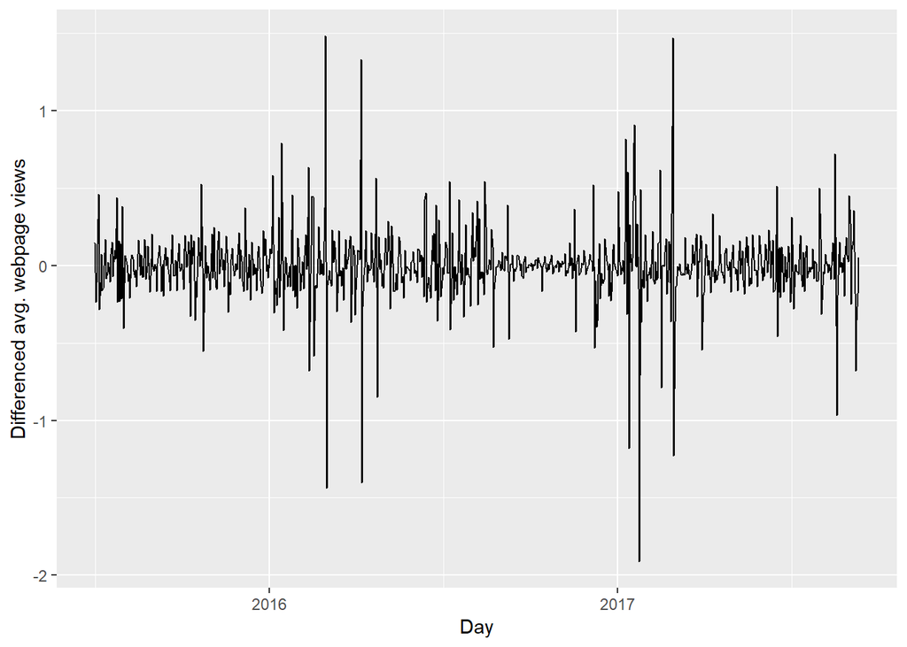

```r
#Number of differencing required
reg_diff_no<-ndiffs(web_daily_avg_ts_summary_dat)
stationary_web_traffic_daily_avg_ts_summary_dat <- diff(web_daily_avg_ts_summary_dat, differences= reg_diff_no)
autoplot(stationary_web_traffic_daily_avg_ts_summary_dat,ylab="Differenced avg. webpage views",xlab="Day")
```

```r
kpss.test(stationary_web_traffic_daily_avg_ts_summary_dat,null="Trend")
```

```
##
##  KPSS Test for Trend Stationarity
##
## data:  stationary_web_traffic_daily_avg_ts_summary_dat
## KPSS Trend = 0.012385, Truncation lag parameter = 6, p-value = 0.1
```

After differencing, it can be observed, that the data is trend stationary.

**Decompose the data: trend, seasonal and error component**

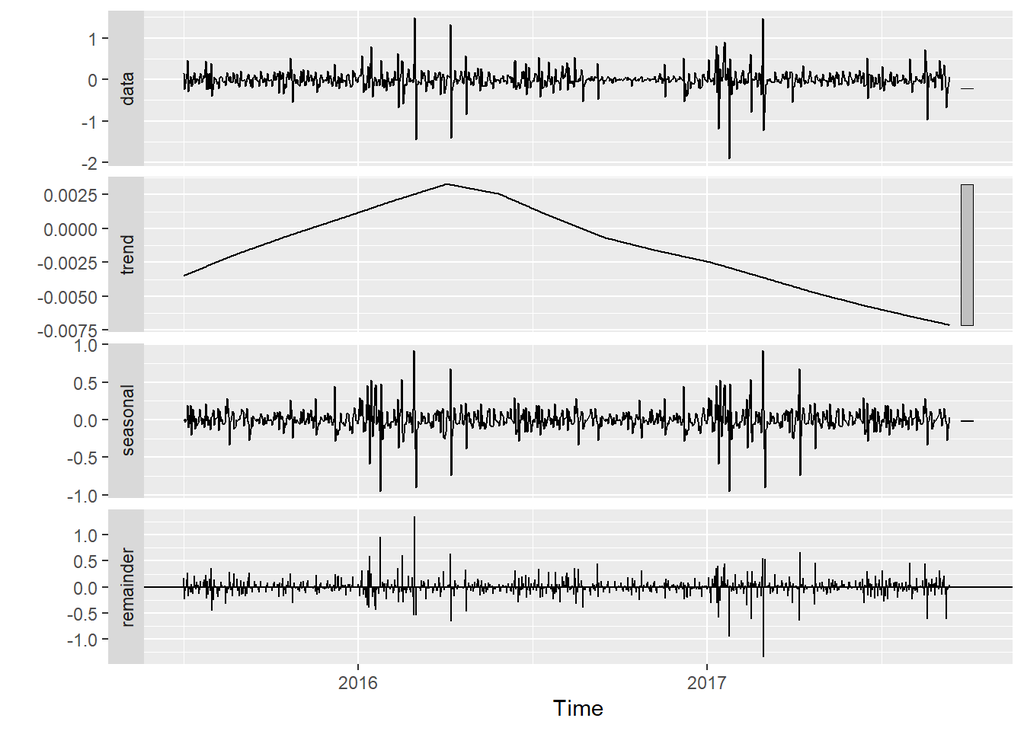

```r
autoplot(stl(stationary_web_traffic_daily_avg_ts_summary_dat[,1],s.window ="periodic"))
```

There’s more seasonal and irregular component than trend in overall avg. web page view

Now, doing the same with the median web page views,

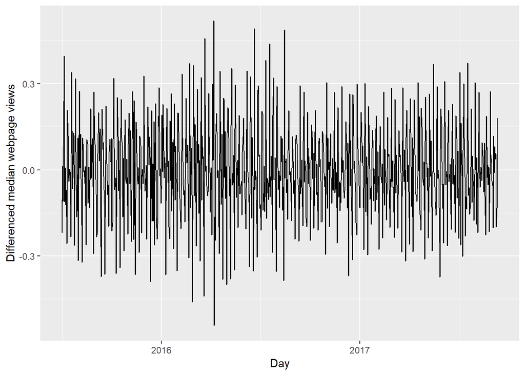

```r
web_daily_median_ts_summary_dat<-ts(data.matrix(log1p(web_daily_summary_dat[,3])),frequency = 365,start=c(2015,as.numeric(format(inds[1], "%j"))))
#kpss.test(web_daily_median_ts_summary_dat,null="Trend")
#Number of differencing required
reg_diff_no<-ndiffs(web_daily_avg_ts_summary_dat)
stationary_web_traffic_daily_median_ts_summary_dat <- diff(web_daily_median_ts_summary_dat, differences= reg_diff_no)
autoplot(stationary_web_traffic_daily_median_ts_summary_dat,ylab="Differenced median webpage views",xlab="Day")
```

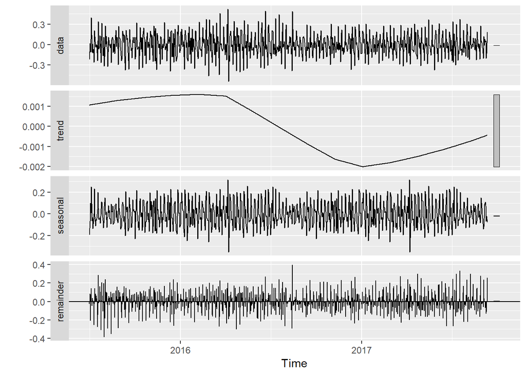

```r
#kpss.test(stationary_web_traffic_daily_median_ts_summary_dat,null="Trend")
autoplot(stl(stationary_web_traffic_daily_median_ts_summary_dat[,1],s.window ="periodic"))
```

We observe the same as what was observed with avg.webpage views.

**Distribution of Web Traffic Plots:**

```r
web_page_summary_dat<-web_data%>%
  group_by(webcode)%>%
  summarise(avg_dailyviews=mean(pageviews,na.rm=TRUE),
            median_dailyviews=median(pageviews,na.rm=TRUE),
            max_dailyviews=max(pageviews,na.rm=TRUE),
            sdbymean_dailyviews=sd(pageviews,na.rm=TRUE)/mean(pageviews,na.rm=TRUE))
setDT(web_page_summary_dat)
web_page_summary_dat<-web_page_summary_dat[!is.na(web_page_summary_dat$avg_dailyviews),]

save(web_page_summary_dat,file="./ENG_WebPage_Summary_Views.RData")
rm(web_page_summary_dat)
```

**Distribution of web views:**

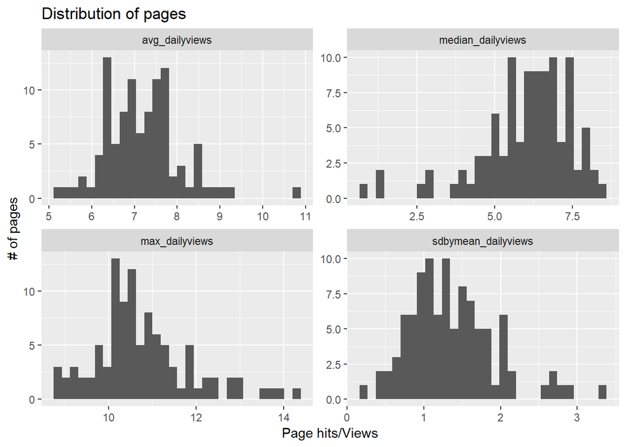

```r
load(file="./ENG_WebPage_Summary_Views.RData")
plot_dat<-melt(web_page_summary_dat[web_page_summary_dat$avg_dailyviews>0,],id="webcode")
ggplot(data = plot_dat)+
  aes(x=log1p(value))+
  geom_histogram()+
  facet_wrap(~variable,scales="free")+
  xlab("Page hits/Views")+
  ylab("# of pages")+
  ggtitle("Distribution of pages")
```

```r
rm(plot_dat)
```

**Web Agent:**

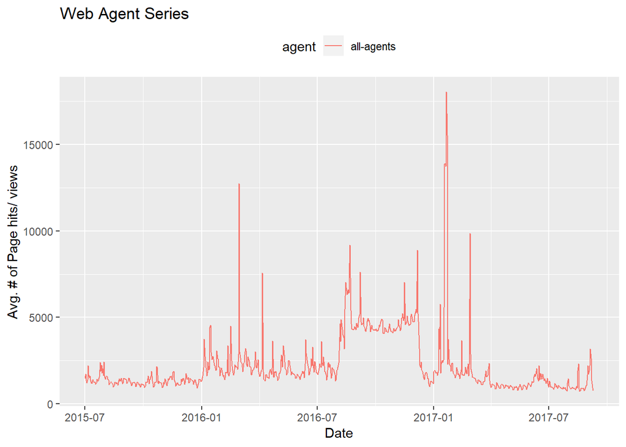

```r
agent<-unique(web_info_data$agent)
web_agent_summary_dat<-data.frame()
for (x in agent){
 pages<-unique(web_info_data$webcode[web_info_data$agent==x])
 setDT(web_data)
 web_temp_dat<-web_data[webcode %in% pages,]
 colnames(web_temp_dat)<-c("webcode","date","pageviews")
web_temp_dat<-web_temp_dat%>%
    group_by(date)%>%
    summarise(avg_dailyviews=mean(pageviews,na.rm=TRUE),
              median_dailyviews=median(pageviews,na.rm=TRUE),
              max_dailyviews=max(pageviews,na.rm=TRUE),
              sdbymean_dailyviews=sd(pageviews,na.rm=TRUE)/mean(pageviews,na.rm=TRUE))
  web_temp_dat$agent<-x
  web_agent_summary_dat<-rbind(web_agent_summary_dat,web_temp_dat)
}
rm(web_temp_dat)

save(web_agent_summary_dat,file="./ENG_WebAgent_Summary_Views.RData")

plot_dat<-melt(web_agent_summary_dat,id=c("date","agent"))
ggplot(data =plot_dat[as.character(plot_dat$variable)=="avg_dailyviews",] )+
  aes(x=date,y=value,colour=agent)+
  geom_line()+
  theme(legend.position = "top")+
  ggtitle("Web Agent Series")+
  xlab("Date")+
  ylab("Avg. # of Page hits/ views")
```

```r
rm(plot_dat)
```

**Web Access:**

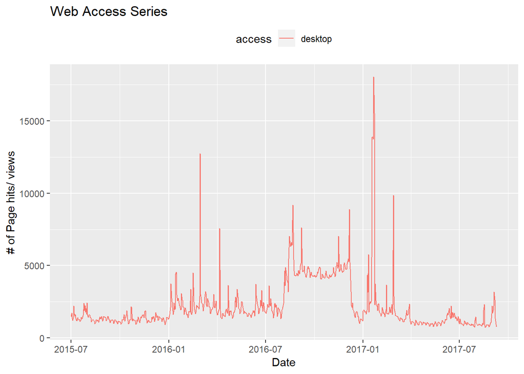

```r
access<-unique(web_info_data$access)
web_acess_summary_dat<-data.frame()
for (x in access){
 pages<-unique(web_info_data$webcode[web_info_data$access==x])
 setDT(web_data)
 web_temp_dat<-web_data[webcode %in% pages,]
web_temp_dat<-web_temp_dat%>%
    group_by(date)%>%
    summarise(avg_dailyviews=mean(pageviews,na.rm=TRUE),
              median_dailyviews=median(pageviews,na.rm=TRUE),
              max_dailyviews=max(pageviews,na.rm=TRUE),
              sdbymean_dailyviews=sd(pageviews,na.rm=TRUE)/mean(pageviews,na.rm=TRUE))
  web_temp_dat$access<-x
  web_acess_summary_dat<-rbind(web_acess_summary_dat,web_temp_dat)
}
rm(web_temp_dat)

save(web_acess_summary_dat,file="./ENG_WebAcess_Summary_Views.RData")

plot_dat<-melt(web_acess_summary_dat,id=c("date","access"))
ggplot(data =plot_dat[as.character(plot_dat$variable)=="avg_dailyviews",] )+
  aes(x=date,y=value,colour=access)+
  geom_line()+
  theme(legend.position = "top")+
  ggtitle("Web Access Series")+
  xlab("Date")+
  ylab("# of Page hits/ views")
```

```r
rm(plot_dat)
```

**Top 10 Webpage Traffic:**

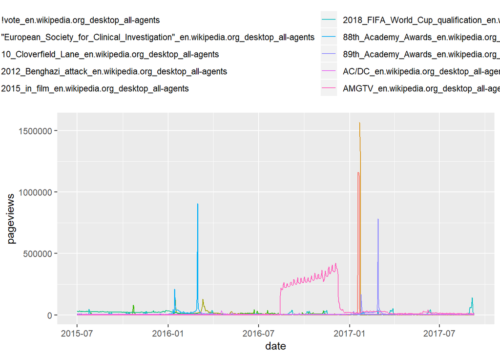

```r
load("./ENG_WebPage_Summary_Views.RData")
top10_webpages<-head(web_page_summary_dat$webcode[order(-web_page_summary_dat$avg_dailyviews)],10)

plot_dat<-web_data[web_data$webcode %in% top10_webpages,]
plot_dat[,pageviews:=as.numeric(pageviews)]
ggplot(plot_dat)+
  aes(x=date,y=pageviews,colour=webcode)+
  geom_line()+
  theme(legend.position = "top")+
guides(colour=guide_legend(nrow=5))
```

## Conclusion:

We will need to explore modelling for time series data in high dimensional spaces, leveraging both spatial and temporal correlations in the multivariate system.

# Baseline Modelling:

## Batch Splitting:

```r
load("./ENG_Web_PageViews_WebPageXDate.RData")
web_data<-web_data%>%
  spread(date,pageviews)
web_data$parallel_grp<-rep(1:60,394)[1:nrow(web_data)]
for(group in unique(web_data$parallel_grp)){
  #print(group)
  web_data_filter<-web_data[web_data$parallel_grp==group,]
  save(web_data_filter,file=paste("./batch_web_data_",group,".RData",sep=""))
}
```

## Running ARIMA Models in Parallel:

Note: This section of code was run on a Linux computing server with 64 Core and 256 GB of RAM for speed.

```r
batch_files<-list.files("./")
batch_files<-batch_files[batch_files %like% "batch_web_data"]
 no_cores <- 1
#no_cores<-detectCores()-2
for(filename in batch_files){

  load(file=paste("./",filename,sep=""))

  predict_parallel_fn<-function(page){
    err<-data.frame()
    tryCatch({

    page_dat<-web_data_filter[web_data_filter$webcode==page,]
    page_dat<-melt(page_dat,id="webcode")
    colnames(page_dat)<-c("webcode","date","pageviews")
    setDT(page_dat)
    page_dat[,date:=as.character(date)]
    page_dat[,date:=str_replace_all(date,"X","")]
    page_dat[,date:=as.Date(date,format="%Y.%m.%d")]
    page_dat[,pageviews:=as.numeric(pageviews)]

    time_series<-ts(log1p(page_dat$pageviews),frequency = 365)
    train_series<-(time_series)[1:(length(time_series)-64)]
    test_series<-(time_series)[(length(time_series)-63):length(time_series)]
    overall_model<-auto.arima(train_series,trace = FALSE)
    order<-paste(overall_model$arma,collapse=" ")
    pred <- forecast(overall_model,h=64)

    err<-cbind(order,
    mean(smape(expm1(train_series),expm1(overall_model$fitted)),na.rm=TRUE),
    page,
    mean(smape(expm1(test_series),expm1(as.numeric(pred$mean))),na.rm=TRUE))
    colnames(err)<-c("order","train_smape","webpage","test_smape")

    rm(page_dat,time_series,train_series,test_series,dates,pred,overall_model,order)
    },error=function(e){cat("ERROR :",conditionMessage(e), "\n")})
    return(err)
}

  results<-mclapply(unique(web_data_filter$webcode),predict_parallel_fn,mc.cores =no_cores)
  resultscombined <-do.call(rbind,results)
  rm(results)

  save(resultscombined,file=paste("./All_ARIMA_Models_",filename,sep=""))
}
```

## Baseline Model Performance

Model was validated on last 64 days of data and the remaining was used for model training

```r
model_results_files<-list.files("./")
model_results_files<-model_results_files[model_results_files %like% "All_ARIMA_Models"]
arima_model_results_file<-data.frame()
for(filename in model_results_files){
  #print(filename)
  filename<-paste0("./",filename)
  load(file=filename)
  arima_model_results_file<-rbind(arima_model_results_file,resultscombined)
}
arima_model_results_file$order<-as.character(arima_model_results_file$order)
arima_model_results_file$webpage<-as.character(arima_model_results_file$webpage)
arima_model_results_file$train_smape<-as.numeric(as.character(arima_model_results_file$train_smape))
arima_model_results_file$test_smape<-as.numeric(as.character(arima_model_results_file$test_smape))
save(arima_model_results_file,file="./ARIMA_Models_AllPage_Results.RData")
```

**Plotting Distribution of train and test SMAPE for ARIMA models:**

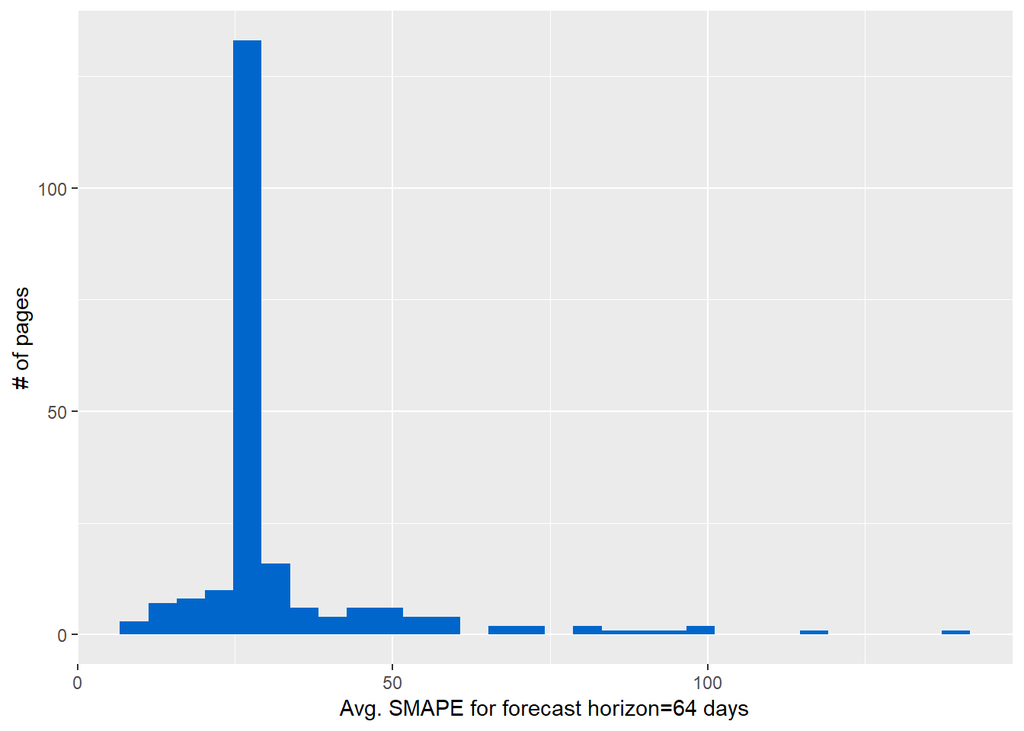

```r
load("./ARIMA_Models_AllPage_Results.RData")
arima_model_results_file<-arima_model_results_file[arima_model_results_file$webpage %like% "en.wikipedia.org",]
plot_dat<-arima_model_results_file[,c("webpage","train_smape","test_smape")]
plot_dat<-melt(plot_dat,id="webpage")
ggplot(plot_dat[plot_dat$variable=="test_smape",])+
  aes(x=value)+
  geom_histogram(fill="#0066CC")+
  xlab("Avg. SMAPE for forecast horizon=64 days")+
  ylab("# of pages")
```

```r
#Train SMAPE
mean(arima_model_results_file$train_smape,na.rm=TRUE)
```

```
## [1] 22.60171
```

```r
#Test SMAPE
mean(arima_model_results_file$test_smape,na.rm=TRUE)
```

```
## [1] 33.65382
```

```r
#Train SMAPE
median(arima_model_results_file$train_smape,na.rm=TRUE)
```

```
## [1] 25.22822
```

```r
#Test SMAPE
median(arima_model_results_file$test_smape,na.rm=TRUE)
```

```
## [1] 29.20589
```

**Plotting for the top 5 web pages:**

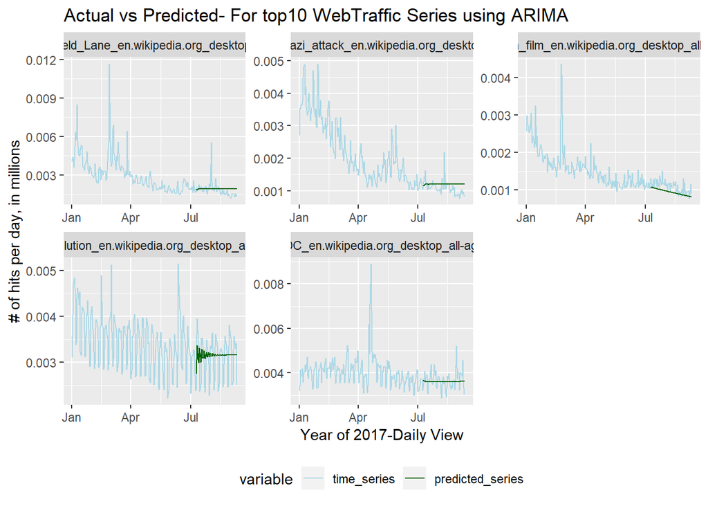

```r
inds <- seq(as.Date("2015-07-01"), as.Date("2017-09-10"), by = "day")
arima_forecast_dat<-data.frame()
load(file="./ENG_WebPage_Summary_Views.RData")
#Uncomment this code to check actual vs forecast for pages that are not main/special and accessed by non-spider agents from any device
# web_page_summary_dat<-web_page_summary_dat[!web_page_summary_dat$webcode %like% "Main" &
#                                              !web_page_summary_dat$webcode %like% "Special" &
#                                              web_page_summary_dat$webcode %like% "all-access" &
#                                              web_page_summary_dat$webcode %like% "all-agent", ]
top10_webcode<-head(web_page_summary_dat$webcode[order(-web_page_summary_dat$median_dailyviews)],5)

for(page in top10_webcode){
  webpage_data<-web_data[web_data$webcode==page,]
  time_series<-ts(log1p(simplify(webpage_data[,2:(ncol(webpage_data)-2)])),frequency = 365)
  train_series<-(time_series)[1:(length(time_series)-64)]
  test_series<-(time_series)[(length(time_series)-63):length(time_series)]
  overall_model<-auto.arima(train_series,trace = FALSE)
  pred <- forecast(overall_model,h=64)$mean
  predicted_series<-ts(c(rep(NA,739),pred),frequency=365)
  arima_forecast<-cbind(time_series,predicted_series)
  arima_forecast<-data.frame(arima_forecast)
  arima_forecast$page<-page
  arima_forecast$date<-inds
  arima_forecast_dat<-rbind(arima_forecast_dat,arima_forecast)
}
plot_dat<-melt(arima_forecast_dat,id=c("page","date"))
ggplot(data=plot_dat[plot_dat$date>="2017-01-01",])+
  aes(x=date,y=expm1(value)/1000000,colour=variable)+
  geom_line()+
  scale_color_manual(values=c("light blue","dark green"))+
  facet_wrap(~page,scales = "free")+
  xlab("Year of 2017-Daily View")+
  ylab("# of hits per day, in millions")+
  ggtitle("Actual vs Predicted- For top10 WebTraffic Series using ARIMA")+
  theme(legend.position = "bottom")
```

As can been observed the ARIMA models, fit well, when the series has a clear trend pattern. However,in series with extreme fluctuations the prediction just returns flat average.

# Experiments:

## Singular Spectrum Analysis and Convolutional Networks:

In this experiment, we will explore using SSA and CNN for forecasting with multivariate high demnsional time series data

We will include the median web views across, different agents, access and locales as additional series into the data, so that the model will account for inherent differences in traffic flow across these types

```r
load(file="./ENG_WebAcess_Summary_Views.RData")
load(file="./ENG_WebAgent_Summary_Views.RData")
load(file="./ENG_Web_PageViews_WebPageXDate.RData")

web_agent_dat<-web_agent_summary_dat[,c("agent","date","median_dailyviews")]
web_agent_dat<-web_agent_dat[!is.na(web_agent_dat$date),]
web_agent_dat<-web_agent_dat%>%spread(date,median_dailyviews)

web_access_dat<-web_acess_summary_dat[,c("access","date","median_dailyviews")]
web_access_dat<-web_access_dat[!is.na(web_access_dat$date),]
web_access_dat<-web_access_dat%>%spread(date,median_dailyviews)


web_data<-web_data%>%
  filter(!is.na(date))%>%
  spread(date,pageviews)

colnames(web_data)[2:ncol(web_data)]<-colnames(web_agent_dat)[2:ncol(web_agent_dat)]
colnames(web_agent_dat)<-colnames(web_data)
colnames(web_access_dat)<-colnames(web_data)

#Combining all the series data together

web_data<-rbind(web_data,web_agent_dat,web_access_dat)

#Reformatting data for feed into SSA
webpage<-unique(web_data$webcode)
webpage<-sort(webpage)
id<-1:nrow(web_data)
names(webpage)<-paste0("web_",ifelse(id<10,paste0("0",id),id))
save(webpage,file="./WebPageOrder.RData")

web_data<-web_data%>%
  gather(key=date,value=pageviews,-webcode)%>%
  mutate(web_id=paste0("web_",ifelse(match(webcode,webpage)<10,paste0("0",match(webcode,webpage)),
                                     match(webcode,webpage))))%>%
  mutate(webcode=NULL)%>%
  spread(web_id,pageviews)
rm(web_access_dat,web_agent_dat)
rm(web_acess_summary_dat,web_agent_summary_dat,web_page_summary_dat)
save(web_data,file="./SSA_WebTraffic_Format_DateXPage.RData")
```

## Preparing for model iteration:

Log-transform data and remove pages with a large number of missing values more than 70%

```r
load(file="./SSA_WebTraffic_Format_DateXPage.RData")
#Log transform variables, so that we remove effect of scales across traffics between low and high traffic pages
web_data[web_data==0]<-NA
web_data[,2:ncol(web_data)]<-log1p(web_data[,2:ncol(web_data)])

#Remove Pages with more than 70% of the  data missing i.e, less than a year of information
#About 2% of webtraffic data is removed-these are mostly same page traffic-diff access/agents
pages_to_remove<-colnames(web_data)[which(colMeans(is.na(web_data)) > 0.70)]
pages_to_remove_sites<-webpage[names(webpage) %in% pages_to_remove]
save(pages_to_remove_sites,file="./RemovedWebPages_ForSSA.RData")

web_data<-web_data[,colnames(web_data)[!colnames(web_data) %in% pages_to_remove]]
rm(pages_to_remove_sites,pages_to_remove)
save(web_data,file="./SSA_WebTraffic_Format_DateXPage_MissingRemoved.RData")
```

## Modelling module:

### CNN Only Model:

This function is used to run a CNN only model on the data,

```r
cnn_model<-function(data,start_period,end_period,pred_window){
set.seed(123)
global_inds<-seq(as.Date("2015-07-01"), as.Date("2017-09-10"), by = "day")
data<-data[match(start_period,global_inds):match(end_period,global_inds),]

pages_to_remove<-colnames(data)[which(colMeans(is.na(data)) > 0.70)]
data<-data[,colnames(data)[!colnames(data) %in% pages_to_remove]]
data<-na.locf(data)

inds <- seq(start_period,end_period, by = "day")
test_dat<-data[match(end_period,inds)-((pred_window-1):0),]
train_dat<-data[match(start_period,inds):(match(end_period,inds)-pred_window),]
rm(global_inds)

vaidate_pred_end<-end_period
vaidate_pred_start<-vaidate_pred_end-(pred_window-1)

train_pred_end<-vaidate_pred_start-1
train_pred_start<-train_pred_end-(pred_window-1)

train_start<-start_period
train_end<-train_pred_start-1

validate_start<-train_start+(pred_window-1)
validate_end<-train_end+(pred_window-1)

train_res_dat<-train_dat[match(train_start,inds):match(train_end,inds),]
mean <- colMeans(train_res_dat)
std <- apply(train_res_dat, 2, sd)
train_res_dat <- scale(train_res_dat, center = mean, scale = std)
train_res_dat[is.na(train_res_dat)]<-0

test_res_dat<-train_dat[match(train_pred_start,inds):match(train_pred_end,inds),]
test_res_dat <- scale(test_res_dat, center = mean, scale = std)
test_res_dat[is.na(test_res_dat)]<-0

validate_input_res_dat<-train_dat[match(validate_start,inds):match(validate_end,inds),]
validate_input_res_dat <- scale(validate_input_res_dat, center = mean, scale = std)
validate_input_res_dat[is.na(validate_input_res_dat)]<-0

encoder_input_data <-train_res_dat
decoder_target_data<-test_res_dat

encoder_input_data<-cbind(t(encoder_input_data),t(decoder_target_data[1:(nrow(decoder_target_data)),]))

encoder_input_data<-array(t(encoder_input_data),dim=c(nrow(encoder_input_data),ncol(encoder_input_data),1))
decoder_target_data<-array(t(decoder_target_data),dim=c(ncol(decoder_target_data),nrow(decoder_target_data),1))


k_clear_session()
n_filters<-32
filter_width<-7
dilation_rates<-2**(0:8)

history_seq<-layer_input(shape=list(NULL,1))
x<-history_seq

for(dilation in dilation_rates){
  x<-x%>%
    layer_conv_1d(filters = n_filters,
                   kernel_size = filter_width,
                   padding='causal',
                   dilation_rate = dilation)
}
x<-x%>%
  layer_dense(units=256, activation='selu')
x<-x%>%
  layer_dropout(0.2)
x<-x%>%
  layer_dense(1)

slice<-function(input,pred_window){
  return(input[,-pred_window:-1,])
}
train_pred_seq<-x%>%
  layer_lambda(slice,arguments=list('pred_window'=(pred_window)))

model<-keras_model(history_seq,train_pred_seq)
#summary(model)

gc()
batch_size<-256
epochs<-2000

optimize_fn<-optimizer_adam(lr=0.001)
k_smape_loss<-function(y_true, y_pred){
  return (k_mean(k_clip(k_abs(y_pred - y_true),0.0,1.0),axis=-1))
}
model %>% compile(optimizer=optimize_fn,
                  loss=k_smape_loss)

history<-model %>% fit(encoder_input_data,decoder_target_data,
                        batch_size=batch_size,
                        epochs=epochs,
                        validation_split=0.3,callbacks =list(
                          callback_early_stopping(monitor="val_loss",patience=10)))

export_savedmodel(model,
                  export_dir_base = paste0("./saveOnlyCNNModel_Final_",start_period,"_",end_period),
                  remove_learning_phase = FALSE)

#Predict 64 days ahead with the current ensembled model
pred_fn<-function(model,input_seq){
  pred_seq<-array(dim=c(nrow(input_seq),(pred_window),1))
  for(step in 1:(pred_window)){
    predict_step<-predict(model,input_seq)
    predict_step<-predict_step[,ncol(predict_step),]
    predict_step<-array(predict_step,dim=c(length(predict_step),1,1))
    pred_seq[,step,] <- predict_step
    input_seq<-input_seq[,,1]
    predict_step<-predict_step[,,1]
    input_seq<-cbind(input_seq,predict_step)
    input_seq<-array(input_seq,dim=c(nrow(input_seq),ncol(input_seq),1))
  }
  return(pred_seq)
}

validation_pred_seq<-pred_fn(model,encoder_input_data)


nn_forecast_dat<-data.frame(t((validation_pred_seq[,,1]*std)+mean))
colnames(nn_forecast_dat)<-colnames(train_dat)
nn_forecast_dat$date<-inds[length(inds)-((pred_window-1):0)]
nn_forecast_dat<-melt(nn_forecast_dat,id=c("date"))
colnames(nn_forecast_dat)<-c("date","web_page","page_views_nn")
nn_forecast_dat$web_page<-as.character(nn_forecast_dat$web_page)

actual_dat<-data.frame(test_dat)
actual_dat$date<-inds[length(inds)-((pred_window-1):0)]
actual_dat<-melt(actual_dat,id="date")
colnames(actual_dat)<-c("date","web_page","page_views")
actual_dat$web_page<-as.character(actual_dat$web_page)

actual_forecast_dat<-merge(nn_forecast_dat,
                           actual_dat,by=c("date","web_page"))

save(actual_forecast_dat,
     file=paste0("./ActualVsForecast_UsingCNN_Data_WebXDay_",start_period,"_",end_period,".RData"))

#Add NN component into forecast
forecast_series<-t((validation_pred_seq[,,1]*std)+mean)

#Compute accuracy metrics for 64 days ahead without NN approach
err_by_timestep_withnn<-data.frame()
for(i in seq(from=7,to=pred_window,by=7)){
  err<-colMeans(smape(expm1(test_dat[1:i,]),expm1(forecast_series[1:i,])))
  rmse<-sqrt(mean((expm1(test_dat[1:i,])-expm1(forecast_series[1:i,]))**2,na.rm=TRUE))
  err_by_timestep_tmp<-cbind(i,mean(err,na.rm=TRUE),median(err),rmse)
  colnames(err_by_timestep_tmp)<-c("n_step","mean_smape","median_smape","rmse")
  err_by_timestep_withnn<-rbind(err_by_timestep_withnn,err_by_timestep_tmp)
}

colnames(err_by_timestep_withnn)[2:ncol(err_by_timestep_withnn)]<-paste0("withNN_",colnames(err_by_timestep_withnn)[2:ncol(err_by_timestep_withnn)])

#Compare metrics for the benefit of a combined approach
err_by_timestep<-err_by_timestep_withnn

err<-smape(expm1(test_dat),expm1(forecast_series))
page_err_Withnn<-colMeans(err)
rmse_withnn<-sqrt(mean((expm1(test_dat)-expm1(forecast_series))**2,na.rm=TRUE))

err_by_timestep$overall_rmse_withtNN<-rmse_withnn
err_by_timestep$overall_SMAPE_withNN<-mean(page_err_Withnn,na.rm=TRUE)
err_by_timestep$start_period<-start_period
err_by_timestep$end_period<-end_period

return(err_by_timestep)

}
```

### Seq. SSA +CNN Model:

This function evaluates Seq. SSA as a standalone approach versus combining it with CNN

```r
ssa_cnn_combined_model_addnFeat<-function(data,start_period,end_period,pred_window){
set.seed(123)
global_inds<-seq(as.Date("2015-07-01"), as.Date("2017-09-10"), by = "day")
data<-data[match(start_period,global_inds):match(end_period,global_inds),]

pages_to_remove<-colnames(data)[which(colMeans(is.na(data)) > 0.70)]
data<-data[,colnames(data)[!colnames(data) %in% pages_to_remove]]
data<-na.locf(data)

inds <- seq(start_period,end_period, by = "day")
test_dat<-data[match(end_period,inds)-((pred_window-1):0),]
train_dat<-data[match(start_period,inds):(match(end_period,inds)-pred_window),]
rm(global_inds)

# Sequential SSA model-First SSA extracts trend
# Second model extracts the seasonal components
# Look at scree plots and eigen vector pairs to identify eigen vectors with similar periods
# A lower lag here would work as this model primarily extracts trend and lowers computational costs
lag<-30
ssa_trend<-ssa(train_dat,kind="mssa",L=lag)
save(ssa_trend,file=paste0("./SSA_Trend3Comp_FinalModel_AddnFeat_AllData_",start_period,"_",end_period,".RData"))
# plot(ssa_trend)
# plot(ssa_trend,type="vectors",idx=1:30)
# plot(ssa_trend,type="paired",idx=1:29)
# plot(ssa_trend,type="wcor")

trend_groups<-list(Trend=c(1,2,3))
reconst_trend <- reconstruct(ssa_trend, groups =trend_groups)
save(reconst_trend,file=paste0("./SSA_Trend3Comp_Reconst_AddnFeat_AllData_",start_period,"_",end_period,".RData"))

#Residuals from the trend model are fed into a seasonal model to identify periodic components
# Use a larger lag here to capture more information, on osciallations, for our dataset 60 worked fine
# General rule: N/2, where N number of observations, say N=365 for 1 year of data
lag_seasonality<-60
res_dat<-attr(reconst_trend,"residuals")
ssa_remaining<-ssa(res_dat,kind="mssa",L=lag_seasonality)
 save(ssa_remaining,file=paste0("./SSA_Remaining_2Seasons_FinalModel_AddnFeat_AllData_",start_period,"_",end_period,".RData"))
# plot(ssa_remaining)
# plot(ssa_remaining,type="vectors",idx=1:50)
# plot(ssa_remaining,type="paired",idx=1:49)
# plot(ssa_remaining,type="wcor")

season_groups<-list(Season1=c(1,2))
reconst_seasonality<-reconstruct(ssa_remaining,groups=season_groups)
 save(reconst_seasonality,file=paste0("./SSA_Seasonal2Comp_Reconst_AddnFeat_AllData_",start_period,"_",end_period,".RData"))

model_noise<-attr(reconst_seasonality,"residuals")
model_noise[is.na(model_noise) |model_noise==Inf | model_noise==(-Inf)]<-0

vaidate_pred_end<-end_period
vaidate_pred_start<-vaidate_pred_end-(pred_window-1)

train_pred_end<-vaidate_pred_start-1
train_pred_start<-train_pred_end-(pred_window-1)

train_start<-start_period
train_end<-train_pred_start-1

validate_start<-train_start+(pred_window-1)
validate_end<-train_end+(pred_window-1)

train_res_dat<-model_noise[match(train_start,inds):match(train_end,inds),]
train_res_dat[is.na(train_res_dat)]<-0

test_res_dat<-model_noise[match(train_pred_start,inds):match(train_pred_end,inds),]
test_res_dat[is.na(test_res_dat)]<-0

validate_input_res_dat<-model_noise[match(validate_start,inds):match(validate_end,inds),]
validate_input_res_dat[is.na(validate_input_res_dat)]<-0

encoder_input_data <-train_res_dat
decoder_target_data<-test_res_dat

encoder_input_data<-cbind(t(encoder_input_data),t(decoder_target_data[1:(nrow(decoder_target_data)-1),]))

median_train_dat<-melt(train_dat)
median_train_dat$Var1<-NULL
median_train_dat$Var2<-as.character(median_train_dat$Var2)
median_train_dat<-median_train_dat%>%
    group_by(Var2)%>%
  summarise(median_views=median(value,na.rm=TRUE))
colnames(median_train_dat)<-c("webpage","median_views")
median_train_dat$webpage<-as.character(median_train_dat$webpage)
median_train_dat<-t(median_train_dat)
colnames(median_train_dat)<-median_train_dat[1,]
median_train_dat<-median_train_dat[2,]
median_train_dat<-matrix(rep(as.numeric(median_train_dat),ncol(encoder_input_data)),byrow=TRUE,nrow=ncol(encoder_input_data))
median_train_dat<-t(median_train_dat)

desktop_traffic<-webpage[webpage %like% "desktop" & names(webpage) %in% colnames(data)]
desktop_traffic_flag<-matrix(as.integer(1.0),length(desktop_traffic),ncol(encoder_input_data))
desktop_traffic_flag<-cbind(data.frame(desktop_traffic_flag),names(desktop_traffic))
colnames(desktop_traffic_flag)[ncol(desktop_traffic_flag)]<-"webpage"

desktop_nottraffic<-webpage[!(webpage %like% "desktop") & names(webpage) %in% colnames(data)]
desktop_nottraffic_flag<-matrix(as.numeric(0.0),length(desktop_nottraffic),ncol(encoder_input_data))
desktop_nottraffic_flag<-cbind(data.frame(desktop_nottraffic_flag),names(desktop_nottraffic))
colnames(desktop_nottraffic_flag)[ncol(desktop_nottraffic_flag)]<-"webpage"

desktop<-rbind(desktop_traffic_flag,desktop_nottraffic_flag)
rm(desktop_nottraffic_flag,desktop_traffic_flag)
desktop<-data.frame(desktop)
desktop<-desktop[order(desktop$webpage),]
desktop$webpage<-NULL
desktop<-data.matrix(desktop)

mobile_traffic<-webpage[webpage %like% "mobile-web" & names(webpage) %in% colnames(data)]
mobile_traffic_flag<-matrix(as.numeric(1.0),length(mobile_traffic),ncol(encoder_input_data))
mobile_traffic_flag<-cbind(data.frame(mobile_traffic_flag),names(mobile_traffic))
colnames(mobile_traffic_flag)[ncol(mobile_traffic_flag)]<-"webpage"

mobile_nottraffic<-webpage[!(webpage %like% "mobile-web") & names(webpage) %in% colnames(data)]
mobile_nottraffic_flag<-matrix(as.numeric(0.0),length(mobile_nottraffic),ncol(encoder_input_data))
mobile_nottraffic_flag<-cbind(data.frame(mobile_nottraffic_flag),names(mobile_nottraffic))
colnames(mobile_nottraffic_flag)[ncol(mobile_nottraffic_flag)]<-"webpage"

mobile<-rbind(mobile_traffic_flag,mobile_nottraffic_flag)
rm(mobile_nottraffic_flag,mobile_traffic_flag)
mobile<-data.frame(mobile)
mobile<-mobile[order(mobile$webpage),]
mobile$webpage<-NULL
mobile<-data.matrix(mobile)

spider_traffic<-webpage[webpage %like% "spider" & names(webpage) %in% colnames(data)]
spider_traffic_flag<-matrix(as.numeric(1.0),length(spider_traffic),ncol(encoder_input_data))
spider_traffic_flag<-cbind(data.frame(spider_traffic_flag),names(spider_traffic))
colnames(spider_traffic_flag)[ncol(spider_traffic_flag)]<-"webpage"
```

```r
spider_nottraffic<-webpage[!(webpage %like% "spider") & names(webpage) %in% colnames(data)]
spider_nottraffic_flag<-matrix(as.numeric(0.0),length(spider_nottraffic),ncol(encoder_input_data))
spider_nottraffic_flag<-cbind(data.frame(spider_nottraffic_flag),names(spider_nottraffic))
colnames(spider_nottraffic_flag)[ncol(spider_nottraffic_flag)]<-"webpage"

spider<-rbind(spider_traffic_flag,spider_nottraffic_flag)
rm(spider_nottraffic_flag,spider_traffic_flag)
spider<-data.frame(spider)
spider<-spider[order(spider$webpage),]
spider$webpage<-NULL
spider<-data.matrix(spider)

encoder_input_data<-array(c(encoder_input_data,median_train_dat,desktop,mobile,spider),dim=c(nrow(encoder_input_data),ncol(encoder_input_data),5))

decoder_target_data<-array((decoder_target_data),dim=c(ncol(decoder_target_data),nrow(decoder_target_data),1))

rm(model_noise)

k_clear_session()
n_filters<-32
filter_width<-7
dilation_rates<-2**(0:8)

history_seq<-layer_input(shape=list(NULL,5))
x<-history_seq

for(dilation in dilation_rates){
  x<-x%>%
    layer_batch_normalization()%>%
    layer_conv_1d(filters = n_filters,
                   kernel_size = filter_width,
                   padding='causal',
                   dilation_rate = dilation)
}
x<-x%>%
  layer_batch_normalization()%>%
  layer_dense(units=256, activation='selu')
x<-x%>%
  layer_dropout(0.2)
x<-x%>%
  layer_batch_normalization()%>%
  layer_dense(1)

slice<-function(input,pred_window){
  return(input[,-pred_window:-1,])
}
train_pred_seq<-x%>%
  layer_lambda(slice,arguments=list('pred_window'=(pred_window)))

model<-keras_model(history_seq,train_pred_seq)
#summary(model)

gc()
batch_size<-256
epochs<-2000

optimize_fn<-optimizer_adam(lr=0.001)
k_smape_loss<-function(y_true, y_pred){
  return (k_mean(k_clip(k_abs(y_pred - y_true),0.0,1.0),axis=-1))
}
model %>% compile(optimizer=optimize_fn,
                  loss="mae")

history<-model %>% fit(encoder_input_data,decoder_target_data,
                        batch_size=batch_size,
                        epochs=epochs,
                        validation_split=0.3,callbacks =list(
                          callback_early_stopping(monitor="val_loss",patience=10)))

export_savedmodel(model,
                  export_dir_base = paste0("./saveCNNModel_Final_AddnFeat_",start_period,"_",end_period),
                  remove_learning_phase = FALSE)

#Predict 64 days ahead with the current ensembled model
pred_fn<-function(model,input_seq){
  pred_seq<-array(dim=c(nrow(input_seq),(pred_window),1))
  for(step in 1:(pred_window)){
    predict_step<-predict(model,input_seq)
    predict_step<-predict_step[,ncol(predict_step),]
    predict_step<-array(predict_step,dim=c(length(predict_step),1,1))
    pred_seq[,step,] <- predict_step
    #input_seq<-input_seq[,,1]
    predict_step<-predict_step[,,1]
    input_seq_new<-cbind(input_seq[,,1],predict_step)
    input_seq_new2<-cbind(input_seq[,,2],input_seq[,(ncol(input_seq)-1),2])
    input_seq_new3<-cbind(input_seq[,,3],input_seq[,(ncol(input_seq)-1),3])
    input_seq_new4<-cbind(input_seq[,,4],input_seq[,(ncol(input_seq)-1),4])
    input_seq_new5<-cbind(input_seq[,,5],input_seq[,(ncol(input_seq)-1),5])
    input_seq<-array(c(input_seq_new,input_seq_new2,input_seq_new3,input_seq_new4,input_seq_new5),dim=c(nrow(input_seq_new),ncol(input_seq_new),5))
  }
  return(pred_seq)
}

validation_pred_seq<-pred_fn(model,encoder_input_data)

forecast_trend <- rforecast(ssa_trend, groups = trend_groups,
                            len = pred_window, only.new = TRUE,
                            drop.attributes = TRUE,
                            cache=FALSE,
                            direction = "column",base="reconstructed")


forecast_remaining<- rforecast(ssa_remaining, groups = season_groups,
                               len = pred_window, only.new = TRUE,
                               drop.attributes = TRUE,
                               cache=FALSE,
                               direction = "column",base="reconstructed")

forecast_series<-forecast_trend+forecast_remaining

trend_dat<-data.frame(forecast_trend)
colnames(trend_dat)<-colnames(train_dat)
trend_dat$date<-inds[length(inds)-((pred_window-1):0)]
trend_dat<-melt(trend_dat,id=c("date"))
colnames(trend_dat)<-c("date","web_page","page_views_trend")
trend_dat$web_page<-as.character(trend_dat$web_page)

seasonal1_dat<-data.frame(forecast_remaining)
colnames(seasonal1_dat)<-colnames(train_dat)
seasonal1_dat$date<-inds[length(inds)-((pred_window-1):0)]
seasonal1_dat<-melt(seasonal1_dat,id=c("date"))
colnames(seasonal1_dat)<-c("date","web_page","page_views_season1")
seasonal1_dat$web_page<-as.character(seasonal1_dat$web_page)

nn_forecast_dat<-data.frame(t(validation_pred_seq[,,1]))
colnames(nn_forecast_dat)<-colnames(train_dat)
nn_forecast_dat$date<-inds[length(inds)-((pred_window-1):0)]
nn_forecast_dat<-melt(nn_forecast_dat,id=c("date"))
colnames(nn_forecast_dat)<-c("date","web_page","page_views_remainingComp")
nn_forecast_dat$web_page<-as.character(nn_forecast_dat$web_page)


forecast_dat_breakdown<-merge(trend_dat,
                           seasonal1_dat,
                           by=c("date","web_page"))

forecast_dat_breakdown<-merge(forecast_dat_breakdown,
                           nn_forecast_dat,
                           by=c("date","web_page"))

actual_dat<-data.frame(test_dat)
actual_dat$date<-inds[length(inds)-((pred_window-1):0)]
actual_dat<-melt(actual_dat,id="date")
colnames(actual_dat)<-c("date","web_page","page_views")
actual_dat$web_page<-as.character(actual_dat$web_page)

actual_forecast_dat<-merge(forecast_dat_breakdown,
                           actual_dat,by=c("date","web_page"))

 save(actual_forecast_dat,
      file=paste0("./ActualVsForecast_AddnFeat_Data_WebXDay_",start_period,"_",end_period,".RData"))

#Compute accuracy metrics for 64 days ahead without NN approach
err_by_timestep_withoutnn<-data.frame()
for(i in seq(from=7,to=pred_window,by=7)){
  err<-colMeans(smape(expm1(test_dat[1:i,]),expm1(forecast_series[1:i,])))
  rmse<-sqrt(mean((expm1(test_dat[1:i,])-expm1(forecast_series[1:i,]))**2,na.rm=TRUE))
  err_by_timestep_tmp<-cbind(i,mean(err,na.rm=TRUE),median(err),rmse)
  colnames(err_by_timestep_tmp)<-c("n_step","mean_smape","median_smape","rmse")
  err_by_timestep_withoutnn<-rbind(err_by_timestep_withoutnn,err_by_timestep_tmp)
}
```

```r
colnames(err_by_timestep_withoutnn)[2:ncol(err_by_timestep_withoutnn)]<-paste0("withoutNN_",colnames(err_by_timestep_withoutnn)[2:ncol(err_by_timestep_withoutnn)])

err<-smape(expm1(test_dat),expm1(forecast_series))
page_err_withoutnn<-colMeans(err)
rmse_withoutnn<-sqrt(mean((expm1(test_dat)-expm1(forecast_series))**2,na.rm=TRUE))

#Add NN component into forecast
forecast_series<-forecast_series+t(validation_pred_seq[,,1])

#Compute accuracy metrics for 64 days ahead without NN approach
err_by_timestep_withnn<-data.frame()
for(i in seq(from=7,to=pred_window,by=7)){
  err<-colMeans(smape(expm1(test_dat[1:i,]),expm1(forecast_series[1:i,])))
  rmse<-sqrt(mean((expm1(test_dat[1:i,])-expm1(forecast_series[1:i,]))**2,na.rm=TRUE))
  err_by_timestep_tmp<-cbind(i,mean(err,na.rm=TRUE),median(err),rmse)
  colnames(err_by_timestep_tmp)<-c("n_step","mean_smape","median_smape","rmse")
  err_by_timestep_withnn<-rbind(err_by_timestep_withnn,err_by_timestep_tmp)
}

colnames(err_by_timestep_withnn)[2:ncol(err_by_timestep_withnn)]<-paste0("withNN_",colnames(err_by_timestep_withnn)[2:ncol(err_by_timestep_withnn)])

#Compare metrics for the benefit of a combined approach
err_by_timestep<-merge(err_by_timestep_withoutnn,
                       err_by_timestep_withnn,by="n_step")

err_by_timestep$overall_SMAPE_withoutNN<-mean(page_err_withoutnn,na.rm=TRUE)
err_by_timestep$overall_rmse_withoutNN<-rmse_withoutnn


err<-smape(expm1(test_dat),expm1(forecast_series))
page_err_Withnn<-colMeans(err)
rmse_withnn<-sqrt(mean((expm1(test_dat)-expm1(forecast_series))**2,na.rm=TRUE))

err_by_timestep$overall_rmse_withtNN<-rmse_withnn
err_by_timestep$overall_SMAPE_withNN<-mean(page_err_Withnn,na.rm=TRUE)
err_by_timestep$start_period<-start_period
err_by_timestep$end_period<-end_period

return(err_by_timestep)

}
```

## Model Validation:

This code chunk does a sliding window cross validation through the data

```r
load(file="./SSA_WebTraffic_Format_DateXPage_MissingRemoved.RData")
load(file="./WebPageOrder.RData")
web_data<-web_data[,colnames(web_data) %in% names(webpage)[webpage %like% "en.wikipedia.org" | webpage %like% "^(desktop|spider|mobile)"]]
start_inds <- seq(as.Date("2015-07-01"), as.Date("2017-09-10"), by = "64 days")
webtraffic_ts_data<-ts(data.matrix(web_data[,2:ncol(web_data)]),frequency = 365,start=c(2015,as.numeric(format(start_inds[1], "%j"))))
rm(web_data)
train_duration<-365
pred_window<-64

validation_results<-data.frame()
cnn_validation_results<-data.frame()

validation_results<-ssa_cnn_combined_model_addnFeat(webtraffic_ts_data,
                       as.Date("2015-07-01"),
                       as.Date("2017-09-10"),
                       pred_window)

cnn_validation_results<-cnn_model(webtraffic_ts_data,
                       as.Date("2015-07-01"),
                       as.Date("2017-09-10"),
                       pred_window)

for(start_ind in start_inds){
start_ind<-as.Date(start_ind)
if((start_ind+pred_window+train_duration)<as.Date("2017-09-10")){
print(paste0("validation Period: ",start_ind," - ",(start_ind+pred_window+train_duration)))

results<-ssa_cnn_combined_model_addnFeat(webtraffic_ts_data,
                       start_ind,
                       as.Date(start_ind+pred_window+train_duration),
                       pred_window)

cnn_results<-cnn_model(webtraffic_ts_data,
                       start_ind,
                       as.Date(start_ind+pred_window+train_duration),
                       pred_window)
validation_results<-rbind(validation_results,results)
cnn_validation_results<-rbind(cnn_validation_results,cnn_results)
}else{
  print("Validation Limit Reached! Terminating Loop")
  break
  }
}
```

```
## [1] "validation Period: 2015-07-01 - 2016-09-02"
## [1] "validation Period: 2015-09-03 - 2016-11-05"
## [1] "validation Period: 2015-11-06 - 2017-01-08"
## [1] "validation Period: 2016-01-09 - 2017-03-13"
## [1] "validation Period: 2016-03-13 - 2017-05-16"
## [1] "validation Period: 2016-05-16 - 2017-07-19"
## [1] "Validation Limit Reached! Terminating Loop"
```

```r
save(validation_results,file="./SSACNNAddnFeat_All_Validation_results.RData")

save(cnn_validation_results,file="./CNN_All_Validation_results.RData")
```

## Results Aggregation:

Combine results from different validation periods and compare them across different forecast horizons

```r
files<-list.files("./")
files<-files[files %like% "ActualVsForecast_AddnFeat_Data_WebXDay"]
validation_results<-data.frame()
for(filename in files){
load(paste0("./",filename))
#print(filename)
global_inds<-seq(min(actual_forecast_dat$date), max(actual_forecast_dat$date), by = "7 days")

actual_forecast_dat$page_views_forecast<-actual_forecast_dat$page_views_trend+
  actual_forecast_dat$page_views_season1+
  actual_forecast_dat$page_views_remainingComp

actual_forecast_dat$smape<-smape(expm1(actual_forecast_dat$page_views),
                                 expm1(actual_forecast_dat$page_views_forecast))

actual_forecast_dat$page_views_forecast<-actual_forecast_dat$page_views_trend+
  actual_forecast_dat$page_views_season1
actual_forecast_dat$smape_wonn<-smape(expm1(actual_forecast_dat$page_views),
                                 expm1(actual_forecast_dat$page_views_forecast))
for(i in global_inds){
  i<-as.Date(i)
  #print(i)
  start_period<-min(actual_forecast_dat$date)
  end_period<-max(actual_forecast_dat$date)
  actual_forecast_dat_tmp<-actual_forecast_dat%>%
    filter(date<=as.Date(i))%>%
    group_by(web_page)%>%
    summarise(mean_smape=mean(smape,na.rm=TRUE),
              mean_smape_wonn=mean(smape_wonn,na.rm=TRUE))
  validation_results_tmp<-cbind(as.Date(start_period),as.Date(end_period),as.Date(i),mean(actual_forecast_dat_tmp$mean_smape),mean(actual_forecast_dat_tmp$mean_smape_wonn))
  colnames(validation_results_tmp)<-c("start_period","end_period","n_step","mean_smape_withnn","mean_smape_withoutnn")
  validation_results<-rbind(validation_results,validation_results_tmp)
  }

}

validation_results$start_period<-as.Date(validation_results$start_period)
validation_results$end_period<-as.Date(validation_results$end_period)
validation_results$n_step<-as.Date(validation_results$n_step)


files<-list.files("./")
files<-files[files %like% "ActualVsForecast_UsingCNN_Data_WebXDay"]
cnn_validation_results<-data.frame()

for(filename in files){
  load(paste0("./",filename))
  #print(filename)
  global_inds<-seq(min(actual_forecast_dat$date), max(actual_forecast_dat$date), by = "7 days")

  actual_forecast_dat$smape_onlynn<-smape(expm1(actual_forecast_dat$page_views),
                                   expm1(actual_forecast_dat$page_views_nn))

  for(i in global_inds){
    i<-as.Date(i)
    #print(i)
    start_period<-min(actual_forecast_dat$date)
    end_period<-max(actual_forecast_dat$date)
    actual_forecast_dat_tmp<-actual_forecast_dat%>%
      filter(date<=as.Date(i))%>%
      group_by(web_page)%>%
      summarise(mean_smape_onlynn=mean(smape_onlynn,na.rm=TRUE))
    validation_results_tmp<-cbind(as.Date(start_period),as.Date(end_period),as.Date(i),
                                  mean(actual_forecast_dat_tmp$mean_smape_onlynn))
    colnames(validation_results_tmp)<-c("start_period","end_period","n_step","mean_smape_onlynn")
    cnn_validation_results<-rbind(cnn_validation_results,validation_results_tmp)
  }

}

cnn_validation_results$start_period<-as.Date(cnn_validation_results$start_period)
cnn_validation_results$end_period<-as.Date(cnn_validation_results$end_period)
cnn_validation_results$n_step<-as.Date(cnn_validation_results$n_step)

new_validation_results<-merge(validation_results,cnn_validation_results,
                              by=c("start_period","end_period","n_step"))
save(new_validation_results,file="./ValidationResults.RData")


new_validation_results$n_step_time<-new_validation_results$n_step-new_validation_results$start_period
new_validation_results$n_step<-NULL

new_validation_results<-new_validation_results%>%
  gather(metric,smape,-start_period,-end_period,-n_step_time)%>%
  spread(n_step_time,smape)

write.csv(new_validation_results,"./Validation_Results.csv")
```

**Histogram of page wise SMAPE for the latest validation perion 2017-07-09 to 2017-09-10, trained on 2015-07-01 to 2017-07-08 data**

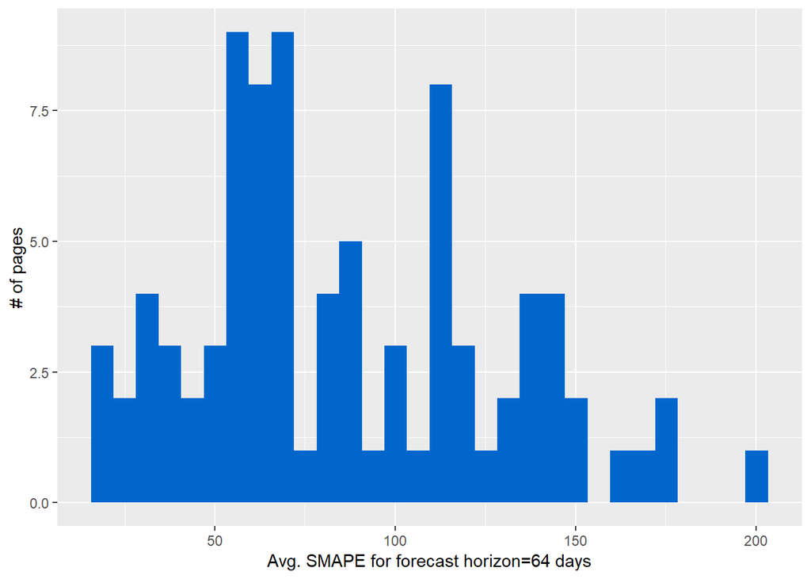

```r
files<-list.files("./")
file<-files[files %like% "ActualVsForecast_AddnFeat_Data_WebXDay_2015-07-01_2017-09-10"]
load(file=paste0("./",files[length(file)]))
actual_forecast_dat$forecast_views<-actual_forecast_dat$page_views_trend+
  actual_forecast_dat$page_views_season1+
  actual_forecast_dat$page_views_remainingComp
actual_forecast_dat$smape_err<-smape(expm1(actual_forecast_dat$page_views),
                                     expm1(actual_forecast_dat$forecast_views))

page_err<-actual_forecast_dat%>%
  group_by(web_page)%>%
  summarise(mean_smape=mean(smape_err,na.rm=TRUE))

#Histogram of page wise SMAPE
ggplot(page_err)+
  aes(x=mean_smape)+
  geom_histogram(fill="#0066CC")+
  xlab("Avg. SMAPE for forecast horizon=64 days")+
  ylab("# of pages")
```

```r
#Mean SMAPE
mean(page_err$mean_smape,na.rm=TRUE)
```

```
## [1] 86.49293
```

```r
#Median SMAPE
median(page_err$mean_smape,na.rm=TRUE)
```

```
## [1] 74.59421
```

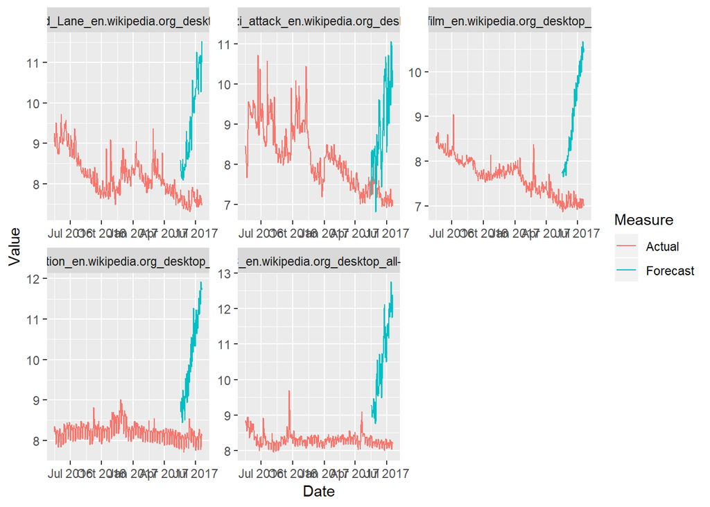

```r
load(file="./ActualVsForecast_AddnFeat_Data_WebXDay_2015-07-01_2017-09-10.RData")
load(file="./ENG_WebPage_Summary_Views.RData")
load(file="./WebPageOrder.RData")
#Uncomment this code to check actual vs forecast for pages that are not main/special and accessed by non-spider agents from any device
# web_page_summary_dat<-web_page_summary_dat[!web_page_summary_dat$webcode %like% "Main" &
#                                              !web_page_summary_dat$webcode %like% "Special" &
#                                              web_page_summary_dat$webcode %like% "all-access" &
#                                              web_page_summary_dat$webcode %like% "all-agent", ]
top10<-head(web_page_summary_dat$webcode[order(-web_page_summary_dat$median_dailyviews)],5)
top10_webcode<-names(webpage[webpage %in% top10])

global_inds<-seq(as.Date("2015-07-01"), as.Date("2017-09-10"), by = "day")
plot_all_dat<-data.frame()
for(webcode in top10_webcode){
  full_data<-webtraffic_ts_data[match(as.Date("2016-05-16"),global_inds):match(as.Date("2017-07-19"),global_inds),webcode]
  forecast_data<-actual_forecast_dat[actual_forecast_dat$web_page==webcode,]
  forecast_data$forecast_views<-forecast_data$page_views_trend+
    forecast_data$page_views_season1+
    forecast_data$page_views_remainingComp
  pred_dat<-c(rep(NA,length(full_data)-64),forecast_data$forecast_views)
plot_dat<-cbind(global_inds[match(as.Date("2016-05-16"),global_inds):match(as.Date("2017-07-19"),global_inds)],full_data,pred_dat)
colnames(plot_dat)<-c("Date","Actual","Forecast")
plot_dat<-data.frame(plot_dat)
plot_dat$Date<-as.Date(plot_dat$Date)
plot_dat$webcode<-webpage[names(webpage)==webcode]
plot_all_dat<-rbind(plot_all_dat,plot_dat)
}

plot_all_dat<-plot_all_dat%>%
  gather(Measure,Value,-Date,-webcode)
ggplot(data=plot_all_dat)+
  aes(x=Date,y=Value,color=Measure)+
  geom_line()+
  facet_wrap(~webcode,scales ="free")
```